# Data Incubator - Hipster Music Taste

We can also right away start giving them new artist to consider looking at by analyzing “Related Artists” to those they have in their playlist. For demonstrative purposes I’ll keep it to the Top 3 Related Artists to every playlist artist to make visualization easier, but it can be done with any number.

My next graph shows, what I think to be one of the coolest ways to visualize Related Artist data: Via a Network graph.

This is a very simple graph because it’s interactive. I’m doing this on purpose to show the user some qualities of the data. For this user (i.e. some jerk named me) we can see this is not a great network. Like, at all. This dude apparently likes to listen to pretty disparate artists which you can pretty clearly see from the zoomed out version of the graph - All artists are related to their 3 “Related Artists” (duh) and for the most part make up their own “small worlds” within this playlist. They don’t really link up to other artists. This is a weakness of the particular dataset only, not the method. You can zoom in, though, which is why simplicity is key here. Right-click or use double fingers (Mac) to zoom into any part of the network you want to see. For the user we highlight the node with the maximum number of connections (both in and out) so we can see, in this example, No Frills Twins is the most central node in this network.

Top Howevermany Lists will probably have better structure because there will be more instances of artists appearing multiple times and artists will probably be more similar (i.e. mostly pop songs or whatever) so their “Related Artists” will overlap. This person is clearly just a hipster.

[interactive chart not shown]

Finally, for the preview, since part of the analyses I want to do are on the lyrical content of the playlists, I have to get the actual lyrics of the songs in addition to the above metrics. The problem with the `spotifyr` is that it doesn’t let you get lyrics of individual songs or of songs in playlists so we have to use a function in the package `geniusr` to do that. The problem with doing THAT is that `geniusr` ALSO doesn’t let you get lyrics by playlist (these packages operate on artist, album, or nothing) so this is where it gets hacky. Here I used a `geniusr` function to search for each song’s lyrics individually and stuck the lyrics (with song title and artist) into their own list. Obviously some songs won’t have their lyrics on **Genius**. When I eventually hook up to **LastFM** this will help.

So the final graph of this project is to give users a sense of what their favorite playlist says about them, lyrically. Are you really inti **Love** or **Cash**? Stick with me though, I know there are a lot of ways to visualize this data but the most fun “*graph*” by far is a Word Cloud and yes, that’s a graph. You ever seen a lyric estimation histogram on Facebook? Didn’t think so.

I guess this weirdo apparently likes…“like.” Wow. That’s some valley girl stuff right there. And you said you were punk. (Sidenote: Sorry not sorry for the swears I love trap music)

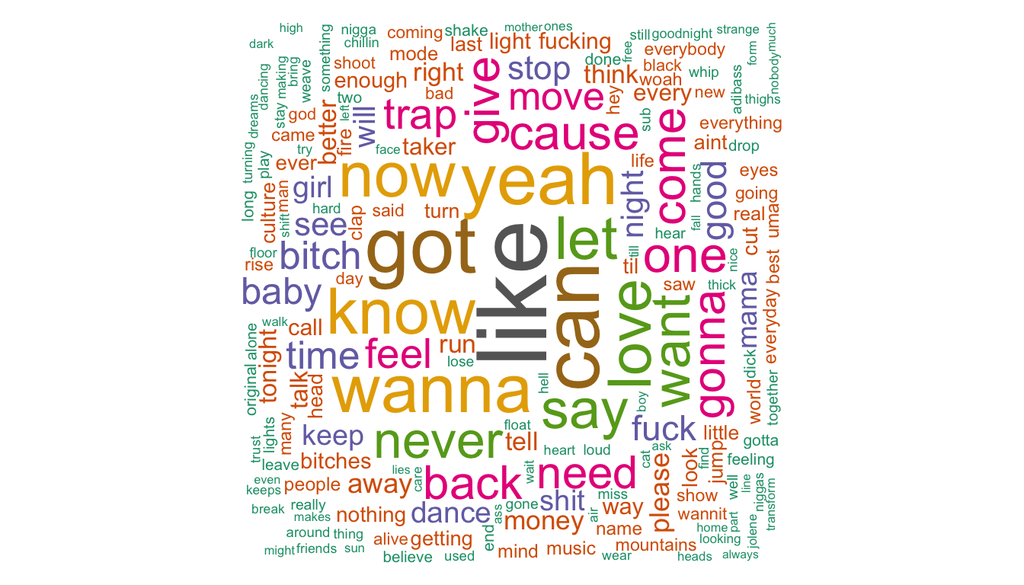

For this analysis I’m also pulling genre information so that can potentially be used for fun metrics or recommendations later on.

However Spotify genre information is crap (i.e. it includes like 9 per artist and is stuff like ‘minimalist bohemial’) so I’m condensing genre listings into main categories for the sake of viewing here.

And apparently although I say I like punk I’m a big liar who loves pop divas instead. You got me. Users will love this information for sure but it will also be useful for eventual recommendations.

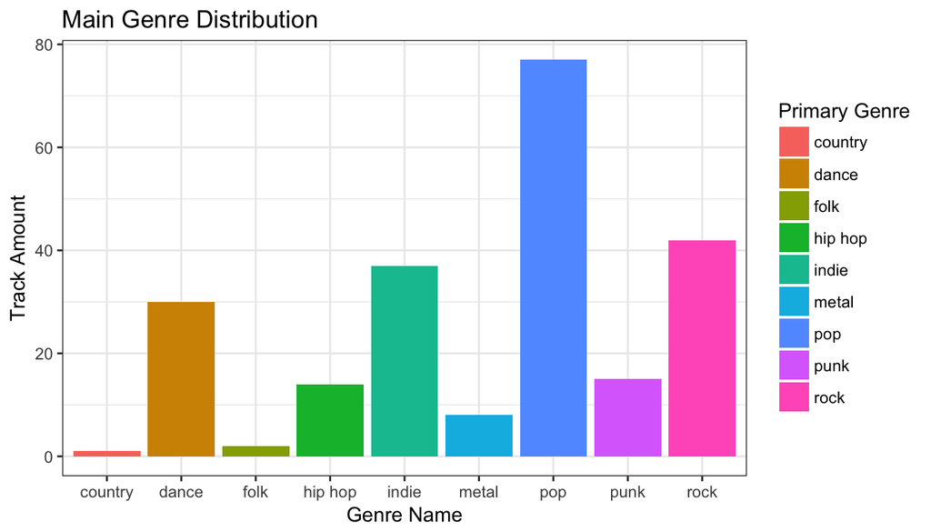

```r
summary_genres <- artist_main_genres %>% group_by(genres) %>% dplyr::summarise(num_genres = n()) %>% ungroup
ggplot(data=summary_genres, aes(x=genres, y=num_genres, fill=genres)) + geom_bar(stat="identity") + scale_fill_hue(name="Primary Genre") + xlab("Genre Name") + ylab("Track Amount") + ggtitle("Main Genre Distribution") + theme_bw()
```

## GOAL 2: COMPARE YOUR METRICS TO POPULAR MUSIC METRICS

### THE WORLD’S MOST WANTED TO KNOW INFORMATION: HOW HIPSTER ARE YOU?

I’m not sure if I’ll finish this in time for the challenge but step 2 is to compare your music taste to the taste of the public. Everyone knows the measure of hipsterness isn’t what kind of craft beer you drink or how long your beard is - it’s how dissimilar your music taste is to the common plebe’s. “I liked Imagine Dragons before they got big” and all that.

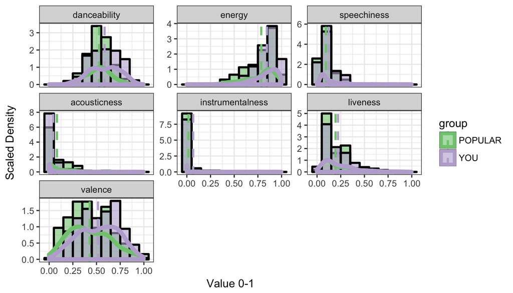

```r
comparison.df <- rbind(USER_metrics.df, BILLBOARD_metrics.df)
groups <- c("YOU", "POPULAR")
comparison.df <- dplyr::mutate(comparison.df, group = rep(groups, c(nrow(USER_metrics.df), nrow(BILLBOARD_metrics.df))))
avgs <- ddply(comparison.df, "group", numcolwise(mean))
#Graph
ds <- melt(comparison.df, id = 8, measure = 1:7)
avg_ds <- melt(avgs, id = 1, measure = 2:8)

ggplot(ds, aes(x=value, y = ..scaled.., fill=group)) + geom_histogram(aes(y=..density..), colour = "black", lwd = 1, binwidth = .1, alpha=.6, position="identity", lwd=.2) + facet_wrap(~ variable, scales = "free_y") + geom_vline(data=avg_ds, aes(xintercept=value, colour = group, lwd = 1), linetype="dashed", size=1) + geom_density(aes(y=..scaled.., colour = group), alpha=0, lwd=2) + theme_bw() + scale_colour_brewer(palette = "Accent") + scale_fill_brewer(palette = "Accent") + ylab("Scaled Density") + xlab("Value 0-1")
```

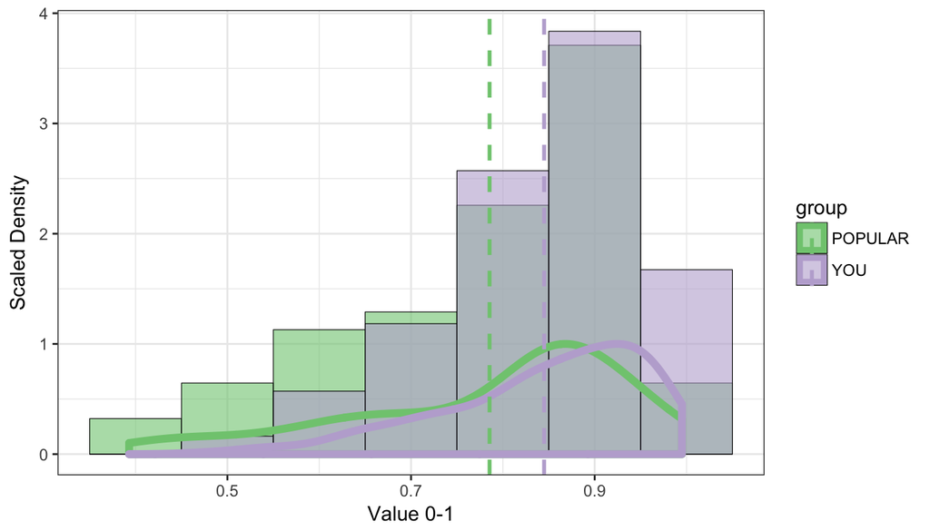

```r
ggplot(data=comparison.df, aes(x=energy, fill=group)) + geom_histogram(aes(y=..density..), colour = "black", binwidth = .1, alpha=.6, position="identity", lwd=.2) + geom_density(aes(y=..scaled.., colour = group), alpha = 0, lwd = 2) + geom_vline(data=avgs, aes(xintercept=energy, colour = group), linetype="dashed", size=1) +theme_bw() + scale_colour_brewer(palette = "Accent") + scale_fill_brewer(palette = "Accent") + ylab("Scaled Density") + xlab("Value 0-1")
```

## GOAL 3: MAKE A RECOMMENDATION SYSTEM BASED ON MUSIC METRICS **AND** LYRICS **AND** TIME

### LET’S SEE IF PEOPLE WHO SAY THEY LOVE MUSIC BECAUSE OF THE LYRICS ARE LYING

Curated playlists already exists and some, like Spotify’s, are pretty good. But when people make recommendation systems the recommended songs are mostly based on what the app thinks are similar bands (i.e. Spotify’s “Related Artist section”) or the metrics extracted above measuring QUALITIES of the MUSIC. That works well enough. But we all know that person who thinks, “Lyrics and singing, on the other hand, are music’s greatest deal-breakers” ( [Thompson, 2013](https://www.npr.org/sections/allsongs/2013/05/29/187168874/the-good-listener-whats-more-important-lyrics-or-music)). So what I’d like to do is create a recommendation system that takes both the metrics AND the lyrics into account as well as a user’s 24-h listening history.

All of this is just the start. The terminal goals are to interface with **Last FM** and then use the lyrical content of the uploaded playlist to generate a playlist with similar content via mchine learning. This will require creating another dataset of songs, all with their metrics and lyrical conent scored and then finding the songs in a similar 2D space (or other). A t-SNE algorithm would be useful here.

Additionally since we’re already interfaced with **Last FM** we can ping data at intervals to get scrobbing data over time (i.e. daily listening history we can break up into 4h bins). We can then look at patterns in 24-h listening history to see if there are circadian patterns of listening (i.e. are you big into ambient at breakfast and hard rock at work?) in order to potentially curate multiple playlists depending on time of day. In an environment where personalization is the moneymaker, this would be the logical next step for streaming services.